# Customer Churn Prediction

```python
# Extract only rows 5 to 10 and columns "MonthlyCharges", "TotalCharges"
df[["MonthlyCharges", "TotalCharges"]].loc[5:10]
```

|  | MonthlyCharges | TotalCharges |
| --- | --- | --- |
| 5 | 99.65 | 820.5 |
| 6 | 89.10 | 1949.4 |
| 7 | 29.75 | 301.9 |
| 8 | 104.80 | 3046.05 |
| 9 | 56.15 | 3487.95 |
| 10 | 49.95 | 587.45 |

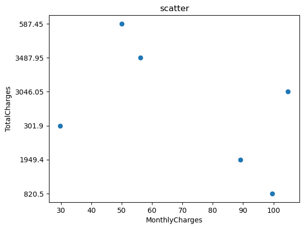

```python
sca=df[["MonthlyCharges", "TotalCharges"]].loc[5:10].reset_index()
plt.scatter(sca["MonthlyCharges"], sca["TotalCharges"])
plt.xlabel("MonthlyCharges")
plt.ylabel("TotalCharges")
plt.title("scatter")
plt.show()
```

What is the difference between loc and iloc? Answer:

loc: Selects data by label (index/column names). iloc: Selects data by integer position (index numbers)

```python
# Extract only rows 5 to 10 and columns "MonthlyCharges", "TotalCharges"
df.loc[[5,10],["MonthlyCharges", "TotalCharges"]]
```

|  | MonthlyCharges | TotalCharges |
| --- | --- | --- |
| 5 | 99.65 | 820.5 |
| 10 | 49.95 | 587.45 |

```python
# Extract only rows 5 to 10 and columns "MonthlyCharges", "TotalCharges"
df.iloc[[5,10],[18,19]]
```

|  | MonthlyCharges | TotalCharges |
| --- | --- | --- |
| 5 | 99.65 | 820.5 |
| 10 | 49.95 | 587.45 |

```python
df[["MonthlyCharges", "TotalCharges"]].head(4)
```

|  | MonthlyCharges | TotalCharges |
| --- | --- | --- |
| 0 | 29.85 | 29.85 |
| 1 | 56.95 | 1889.5 |
| 2 | 53.85 | 108.15 |
| 3 | 42.30 | 1840.75 |

✅ 1. Filter rows where multiple conditions are true Q: How do you filter rows where:

Churn is "Yes" MonthlyCharges is greater than 80 Contract is "Month-to-month"

```python
mn=df[(df["Churn"]=="Yes") & (df["MonthlyCharges"]>=80) & (df["Contract"]=="Month-to-month")]
mn.head()
```

[output not shown]

5 rows × 22 columns

```python
# Q: How do you find rows where the TotalCharges column is missing?
df["TotalCharges"].isnull().sum()
```

```
0
```

```python
# Q: How do you filter rows where PaymentMethod contains the word "Credit"?
filter=df[(df["PaymentMethod"]=="Credit card (automatic)")]
filter
```

[output not shown]

1522 rows × 22 columns

```python
# Q: How do you find rows where Contract is either "One year" or "Two year"?
contract=df[(df["Contract"]=="One year") | (df["Contract"]=="Two year")]
contract
```

[output not shown]

3168 rows × 22 columns

```python
# Q: How do you find rows where tenure is between 12 and 36 months?
between=df[df["tenure"].between(12,36)]
between
```

[output not shown]

1973 rows × 22 columns

```python
# Q: How do you find all duplicate customerID rows?
df["customerID"].duplicated().sum()
```

```
0
```

Q: Filter customers with:

MonthlyCharges greater than ₹100 Churn is "Yes"

```python
filter=df[(df["MonthlyCharges"]>100) & (df["Churn"]=="Yes")]
filter
```

|  | customerID | gender | SeniorCitizen | Partner | Dependents | tenure | PhoneService | MultipleLines | InternetService | OnlineSecurity | ... | StreamingTV | StreamingMovies | Contract | PaperlessBilling | PaymentMethod | MonthlyCharges | TotalCharges | Churn | Customer Type | TotalCost |
| --- | --- | --- | --- | --- | --- | --- | --- | --- | --- | --- | --- | --- | --- | --- | --- | --- | --- | --- | --- | --- | --- |
| 8 | 7892-POOKP | Female | 0 | Yes | No | 28 | Yes | Yes | Fiber optic | No | ... | Yes | Yes | Month-to-month | Yes | Electronic check | 104.80 | 3046.05 | Yes | good | 2934.40 |
| 13 | 0280-XJGEX | Male | 0 | No | No | 49 | Yes | Yes | Fiber optic | No | ... | Yes | Yes | Month-to-month | Yes | Bank transfer (automatic) | 103.70 | 5036.3 | Yes | good | 5081.30 |
| 38 | 5380-WJKOV | Male | 0 | No | No | 34 | Yes | Yes | Fiber optic | No | ... | Yes | Yes | Month-to-month | Yes | Electronic check | 106.35 | 3549.25 | Yes | good | 3615.90 |
| 104 | 3192-NQECA | Male | 0 | Yes | No | 68 | Yes | Yes | Fiber optic | No | ... | Yes | Yes | Two year | Yes | Bank transfer (automatic) | 110.00 | 7611.85 | Yes | good | 7480.00 |
| 117 | 5299-RULOA | Female | 0 | Yes | Yes | 10 | Yes | Yes | Fiber optic | Yes | ... | Yes | Yes | Month-to-month | Yes | Electronic check | 100.25 | 1064.65 | Yes | medium | 1002.50 |
| ... | ... | ... | ... | ... | ... | ... | ... | ... | ... | ... | ... | ... | ... | ... | ... | ... | ... | ... | ... | ... | ... |
| 6952 | 6394-MFYNG | Female | 0 | No | No | 48 | Yes | Yes | Fiber optic | No | ... | Yes | Yes | Month-to-month | Yes | Bank transfer (automatic) | 107.40 | 5121.3 | Yes | good | 5155.20 |
| 6962 | 0886-QGENL | Female | 1 | Yes | No | 27 | Yes | No | Fiber optic | Yes | ... | Yes | Yes | Month-to-month | Yes | Electronic check | 101.25 | 2754.45 | Yes | good | 2733.75 |
| 6972 | 6664-FPDAC | Female | 1 | No | No | 56 | Yes | Yes | Fiber optic | No | ... | Yes | Yes | One year | Yes | Electronic check | 111.95 | 6418.9 | Yes | good | 6269.20 |
| 7006 | 0093-XWZFY | Male | 0 | No | No | 40 | Yes | Yes | Fiber optic | No | ... | Yes | Yes | Month-to-month | Yes | Credit card (automatic) | 104.50 | 4036.85 | Yes | good | 4180.00 |
| 7034 | 0639-TSIQW | Female | 0 | No | No | 67 | Yes | Yes | Fiber optic | Yes | ... | Yes | No | Month-to-month | Yes | Credit card (automatic) | 102.95 | 6886.25 | Yes | good | 6897.65 |

253 rows × 23 columns

```python
# Q: Get the count of each unique value in the Churn column.
df["Churn"].value_counts()
```

```
Churn
No     5174
Yes    1869
Name: count, dtype: int64
```

```python
df["InternetService"].value_counts()
```

```
InternetService
Fiber optic    3096
DSL            2421
No             1526
Name: count, dtype: int64
```

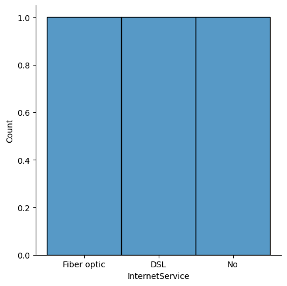

```python
co=df["InternetService"].value_counts().reset_index()
sns.displot(x=co["InternetService"], data=df)
plt.show()
```

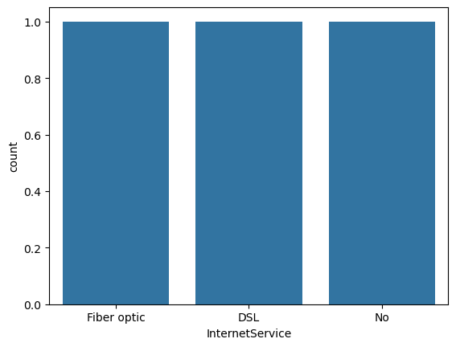

```python
co=df["InternetService"].value_counts().reset_index()
sns.countplot(x=co["InternetService"], data=df)
plt.show()
```

```python
# Q: Sort the DataFrame by MonthlyCharges in descending order.
df.sort_values("MonthlyCharges",ascending=False)
```

[output not shown]

7043 rows × 22 columns